# 1 Data Manipulation `nycflights13`

## 1.1 Problem 1: What months had the highest and lowest proportion of cancelled flights? Interpret any seasonal patterns.

To determine if a flight was cancelled use the following code

```r
# What months had the highest and lowest % of cancelled flights?

pct_share <- flights %>%
  filter(is.na(dep_time)) %>%
  group_by(month) %>%
  summarise(Count = n()) %>%
  mutate(pct_share = Count * 100 / sum(Count)) %>%
  arrange(desc(pct_share))

print(pct_share)
```

```
## # A tibble: 12 × 3
##    month Count pct_share
##    <int> <int>     <dbl>
##  1     2  1261     15.3
##  2    12  1025     12.4
##  3     6  1009     12.2
##  4     7   940     11.4
##  5     3   861     10.4
##  6     4   668      8.09
##  7     5   563      6.82
##  8     1   521      6.31
##  9     8   486      5.89
## 10     9   452      5.48
## 11    10   236      2.86
## 12    11   233      2.82
```

## 1.2 Problem 2: What plane (specified by the `tailnum` variable) traveled the most times from New York City airports in 2013?

Please `left_join()` the resulting table with the table `planes` (also included in the `nycflights13` package).

For the plane with the greatest number of flights and that had more than 50 seats, please create a table where it flew to during 2013.

```r
most_flown <- flights %>%
  group_by(tailnum) %>%
  summarise(count = n()) %>%
  arrange(desc(count)) %>%
  left_join(planes, by = "tailnum") %>%
  filter(!is.na(tailnum))

print(most_flown)
```

```
## # A tibble: 4,043 × 10
##    tailnum count  year type        manufacturer model engines seats speed engine
##    <chr>   <int> <int> <chr>       <chr>        <chr>   <int> <int> <int> <chr>
##  1 N725MQ    575    NA <NA>        <NA>         <NA>       NA    NA    NA <NA>
##  2 N722MQ    513    NA <NA>        <NA>         <NA>       NA    NA    NA <NA>
##  3 N723MQ    507    NA <NA>        <NA>         <NA>       NA    NA    NA <NA>
##  4 N711MQ    486  1976 Fixed wing… GULFSTREAM … G115…       2    22    NA Turbo…
##  5 N713MQ    483    NA <NA>        <NA>         <NA>       NA    NA    NA <NA>
##  6 N258JB    427  2006 Fixed wing… EMBRAER      ERJ …       2    20    NA Turbo…
##  7 N298JB    407  2009 Fixed wing… EMBRAER      ERJ …       2    20    NA Turbo…
##  8 N353JB    404  2012 Fixed wing… EMBRAER      ERJ …       2    20    NA Turbo…
##  9 N351JB    402  2012 Fixed wing… EMBRAER      ERJ …       2    20    NA Turbo…
## 10 N735MQ    396    NA <NA>        <NA>         <NA>       NA    NA    NA <NA>
## # ℹ 4,033 more rows
```

```r
most_flown_dest_2013 <- most_flown %>%
  filter(seats > 50) %>%
  head(1) %>%
  left_join(flights, by = "tailnum") %>%
  group_by(carrier, dest) %>%
  count()

print(most_flown_dest_2013)
```

```
## # A tibble: 6 × 3
## # Groups:   carrier, dest [6]
##   carrier dest      n
##   <chr>   <chr> <int>
## 1 AA      BOS       1
## 2 AA      LAX     313
## 3 AA      MCO       1
## 4 AA      MIA      25
## 5 AA      SFO      52
## 6 AA      SJU       1
```

## 1.3 Problem 3: Use the `flights` and `planes` tables to answer the following questions:

```
-   How many planes have a missing date of manufacture?
-   What are the five most common manufacturers?
-   Has the distribution of manufacturer changed over time as reflected by the airplanes flying from NYC in 2013? (Hint: you may need to use case_when() to recode the manufacturer name and collapse rare vendors into a category called Other.)
```

- How many planes have a missing date of manufacture?

```r
# Missing date of manufacture
missing_year <- planes %>%
  filter(is.na(year)) %>%
  count()
print(missing_year)
```

```
## # A tibble: 1 × 1
##       n
##   <int>
## 1    70
```

```r
# Cleaning the dataset - combining same manufacturers, adding an others category
planes_clean <- planes %>%
  mutate(
    manufacturer = case_when(
    manufacturer == 'BOEING' ~ 'BOEING',
    manufacturer == 'AIRBUS' ~ 'AIRBUS',
    manufacturer == 'AIRBUS INDUSTRIE' ~ 'AIRBUS',
    manufacturer == 'EMBRAER' ~ 'EMBRAER',
    manufacturer == 'BOMBARDIER INC' ~ 'BOMBARDIER INC',
    manufacturer == 'MCDONNELL DOUGLAS' ~ 'MCDONNELL DOUGLAS',
    manufacturer == 'MCDONNELL DOUGLAS AIRCRAFT CO' ~ 'MCDONNELL DOUGLAS',
    manufacturer == 'MCDONNELL DOUGLAS CORPORATION' ~ 'MCDONNELL DOUGLAS',
    TRUE ~ 'OTHER'
    )
  )

# Most common manufacturers
common_manuf <- planes_clean %>%
  count(manufacturer, sort = TRUE) %>%
  head(5)
print(common_manuf)
```

```
## # A tibble: 5 × 2
##   manufacturer          n
##   <chr>             <int>
## 1 BOEING             1630
## 2 AIRBUS              736
## 3 BOMBARDIER INC      368
## 4 EMBRAER             299
## 5 MCDONNELL DOUGLAS   237
```

```r
# Manufacturer distribution
manuf_dist <- planes_clean %>%
  left_join(flights, by = 'tailnum') %>%
  group_by(month, manufacturer) %>%
  summarise(count = n())
print(manuf_dist)
```

```
## # A tibble: 72 × 3
## # Groups:   month [12]
##    month manufacturer      count
##    <int> <chr>             <int>
##  1     1 AIRBUS             7283
##  2     1 BOEING             6623
##  3     1 BOMBARDIER INC     1925
##  4     1 EMBRAER            5364
##  5     1 MCDONNELL DOUGLAS   872
##  6     1 OTHER               458
##  7     2 AIRBUS             6654
##  8     2 BOEING             6048
##  9     2 BOMBARDIER INC     1809
## 10     2 EMBRAER            4908
## # ℹ 62 more rows
```

## 1.4 Problem 4: Which carriers service the route to San Francisco International (SFO).

Join the `flights` and `airlines` tables and count which airlines flew the most to SFO. Produce a new dataframe, `fly_into_sfo` that contains three variables: the `name` of the airline, e.g., `United Air Lines Inc.` not `UA`, the count (number) of times it flew to SFO, and the `percent` of the trips that that particular airline flew to SFO.

```r
fly_into_sfo <- flights %>%
  filter(dest == 'SFO') %>%
  count(carrier, sort = TRUE) %>%
  left_join(airlines, by = 'carrier') %>%
  mutate( pct = n / sum(n)) %>%
  select(name, n, pct)
print(fly_into_sfo)
```

```
## # A tibble: 5 × 3
##   name                       n    pct
##   <chr>                  <int>  <dbl>
## 1 United Air Lines Inc.   6819 0.512
## 2 Virgin America          2197 0.165
## 3 Delta Air Lines Inc.    1858 0.139
## 4 American Airlines Inc.  1422 0.107
## 5 JetBlue Airways         1035 0.0776
```

And here is some bonus ggplot code to plot your dataframe

```r
sfo_plot <- fly_into_sfo %>%

  # sort 'name' of airline by the numbers it times to flew to SFO
  mutate(name = fct_reorder(name, n)) %>%

  ggplot() +

  aes(x = n,
      y = name) +

  # a simple bar/column plot
  geom_col() +

  # add labels, so each bar shows the % of total flights
  geom_text(aes(label = pct),
             hjust = 1,
             colour = "white",
             size = 3)+

  # add labels to help our audience
  labs(title="Which airline dominates the NYC to SFO route?",
       subtitle = "as % of total flights in 2013",
       x= "Number of flights",
       y= NULL) +

  theme_bw() +

  # change the theme-- i just googled those , but you can use the ggThemeAssist add-in
  # https://cran.r-project.org/web/packages/ggThemeAssist/index.html

  theme(#
    # so title is left-aligned
    plot.title.position = "plot",

    # text in axes appears larger
    axis.text = element_text(size=12),

    # title text is bigger
    plot.title = element_text(size=18)
      ) +

  # add one final layer of NULL, so if you comment out any lines
  # you never end up with a hanging `+` that awaits another ggplot layer
  NULL

print(sfo_plot)
```

[output not shown]

## 1.5 Problem 5: Cancellations of flights to SFO.

We create a new dataframe `cancellations` as follows

```r
cancellations <- flights %>%

  # just filter for destination == 'SFO'
  filter(dest == 'SFO') %>%

  # a cancelled flight is one with no `dep_time`
  filter(is.na(dep_time))
```

I want you to think how we would organise our data manipulation to create the following plot. No need to write the code, just explain in words how you would go about it.

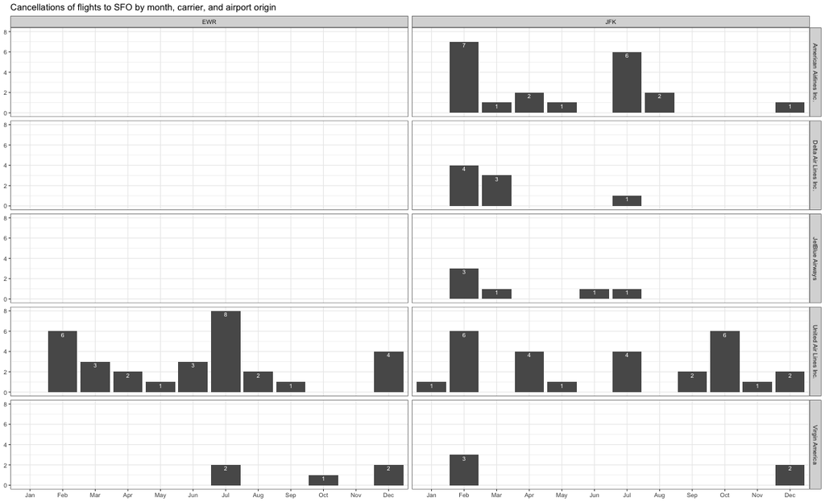

To recreate the graph starting with the cancellations dataset, I would:

1. **Group and Summarize**:
   - Group the filtered data by **`month`**, **`carrier`**, and **`origin`**.
   - Summarize the grouped data to count the number of cancellations within each group.
2. **Prepare Data for Plotting**:
   - Convert **`month`** to a factor to ensure the months are plotted in order.
3. **Plot the Data**:
   - Use **`ggplot`** to create a bar plot.
   - Map **`month`** to the x-axis and the count of cancellations to the y-axis.
   - Use **`facet_grid`** to create separate panels for each origin airport.
   - Use **`geom_bar`** to create the bar plot

# 2 Rents in San Francsisco 2000-2018

[Kate Pennington](https://www.katepennington.org/data) created a panel of historic Craigslist rents by scraping posts archived by the Wayback Machine. You can read more about her work here

[What impact does new housing have on rents, displacement, and gentrification in the surrounding neighborhood? Read our interview with economist Kate Pennington about her article, “Does Building New Housing Cause Displacement?:The Supply and Demand Effects of Construction in San Francisco.”](https://matrix.berkeley.edu/research-article/kate-pennington-on-gentrification-and-displacement-in-san-francisco/)

In our case, we have a clean(ish) dataset with about 200K rows that correspond to Craigslist listings for renting properties in the greater SF area. The data dictionary is as follows

| variable | class | description |
| --- | --- | --- |
| post_id | character | Unique ID |
| date | double | date |
| year | double | year |
| nhood | character | neighborhood |
| city | character | city |
| county | character | county |
| price | double | price in USD |
| beds | double | n of beds |
| baths | double | n of baths |
| sqft | double | square feet of rental |
| room_in_apt | double | room in apartment |
| address | character | address |
| lat | double | latitude |
| lon | double | longitude |
| title | character | title of listing |
| descr | character | description |
| details | character | additional details |

The dataset was used in a recent [tidyTuesday](https://github.com/rfordatascience/tidytuesday) project.

```r
# download directly off tidytuesdaygithub repo

rent <- readr::read_csv('https://raw.githubusercontent.com/rfordatascience/tidytuesday/master/data/2022/2022-07-05/rent.csv')
```

What are the variable types? Do they all correspond to what they really are? Which variables have most missing values?

```r
# YOUR CODE GOES HERE
skimr::skim(rent)
```

Data summary

| Name | rent |
| --- | --- |
| Number of rows | 200796 |
| Number of columns | 17 |
| _______________________ |  |
| Column type frequency: |  |
| character | 8 |
| numeric | 9 |
| ________________________ |  |
| Group variables | None |

**Variable type: character**

| skim_variable | n_missing | complete_rate | min | max | empty | n_unique | whitespace |
| --- | --- | --- | --- | --- | --- | --- | --- |
| post_id | 0 | 1.00 | 9 | 14 | 0 | 200796 | 0 |
| nhood | 0 | 1.00 | 4 | 43 | 0 | 167 | 0 |
| city | 0 | 1.00 | 5 | 19 | 0 | 104 | 0 |
| county | 1394 | 0.99 | 4 | 13 | 0 | 10 | 0 |
| address | 196888 | 0.02 | 1 | 38 | 0 | 2869 | 0 |
| title | 2517 | 0.99 | 2 | 298 | 0 | 184961 | 0 |
| descr | 197542 | 0.02 | 13 | 16975 | 0 | 3025 | 0 |
| details | 192780 | 0.04 | 4 | 595 | 0 | 7667 | 0 |

**Variable type: numeric**

| skim_variable | n_missing | complete_rate | mean | sd | p0 | p25 | p50 | p75 | p100 | hist |
| --- | --- | --- | --- | --- | --- | --- | --- | --- | --- | --- |
| date | 0 | 1.00 | 20095718.38 | 44694.07 | 20000902.00 | 20050227.00 | 20110924.00 | 20120805.0 | 20180717.00 | ▁▇▁▆▃ |
| year | 0 | 1.00 | 2009.51 | 4.48 | 2000.00 | 2005.00 | 2011.00 | 2012.0 | 2018.00 | ▁▇▁▆▃ |
| price | 0 | 1.00 | 2135.36 | 1427.75 | 220.00 | 1295.00 | 1800.00 | 2505.0 | 40000.00 | ▇▁▁▁▁ |
| beds | 6608 | 0.97 | 1.89 | 1.08 | 0.00 | 1.00 | 2.00 | 3.0 | 12.00 | ▇▂▁▁▁ |
| baths | 158121 | 0.21 | 1.68 | 0.69 | 1.00 | 1.00 | 2.00 | 2.0 | 8.00 | ▇▁▁▁▁ |
| sqft | 136117 | 0.32 | 1201.83 | 5000.22 | 80.00 | 750.00 | 1000.00 | 1360.0 | 900000.00 | ▇▁▁▁▁ |
| room_in_apt | 0 | 1.00 | 0.00 | 0.04 | 0.00 | 0.00 | 0.00 | 0.0 | 1.00 | ▇▁▁▁▁ |
| lat | 193145 | 0.04 | 37.67 | 0.35 | 33.57 | 37.40 | 37.76 | 37.8 | 40.43 | ▁▁▅▇▁ |
| lon | 196484 | 0.02 | -122.21 | 0.78 | -123.20 | -122.42 | -122.26 | -122.0 | -74.20 | ▇▁▁▁▁ |

Make a plot that shows the top 20 cities in terms of % of classifieds between 2000-2018. You need to calculate the number of listings by city, and then convert that number to a %.

The final graph should look like this

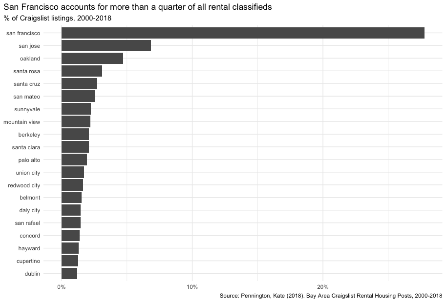

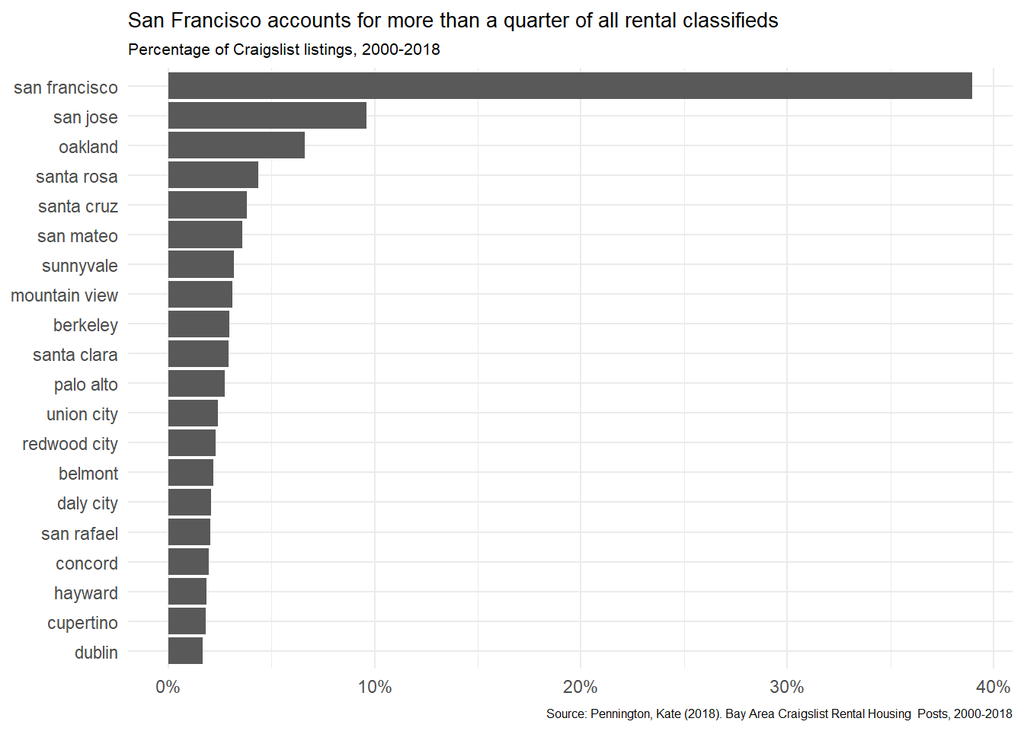

```r
# YOUR CODE GOES HERE
rent %>%
  count(city, sort = TRUE) %>%
  head(20) %>%
  mutate(
    pct = n / sum(n),
    city = fct_reorder(city, pct)
    ) %>%

  ggplot() +
  aes(x = pct, y = city) +
  geom_col() +
  scale_x_continuous( labels = scales::percent_format()) +
  labs(
    title = "San Francisco accounts for more than a quarter of all rental classifieds",
    subtitle = "Percentage of Craigslist listings, 2000-2018",
    caption = "Source: Pennington, Kate (2018). Bay Area Craigslist Rental Housing  Posts, 2000-2018",
    x = NULL,  # Removes the 'pct' label on x-axis
    y = NULL   # Removes the 'city' label on y-axis
  ) +
  theme_minimal() +
    theme(
    plot.title = element_text(size = 10, hjust = 0),
    plot.subtitle = element_text(size = 8, hjust = 0),
    plot.caption = element_text(size = 6)
  )
```

Make a plot that shows the evolution of median prices in San Francisco for 0, 1, 2, and 3 bedrooms listings. The final graph should look like this

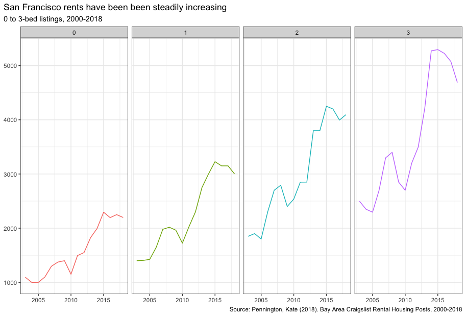

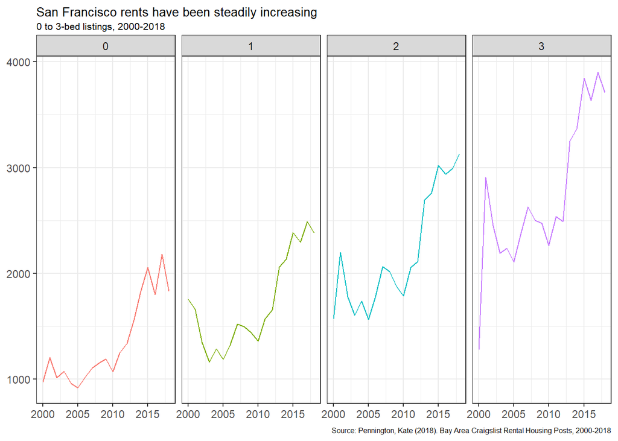

```r
# YOUR CODE GOES HERE
rent %>%
  group_by(beds, year) %>%
  summarise(median_price = mean(price, na.rm = TRUE)) %>%
  filter(beds %in% c(0,1,2,3)) %>%
  ggplot() +
  aes(x = year, y = median_price, color = as.factor(beds)) +
  geom_line() +
  facet_wrap(~beds, ncol = 4) +
  theme_bw() +
  labs(
    title = 'San Francisco rents have been steadily increasing',
    subtitle = '0 to 3-bed listings, 2000-2018',
    caption = 'Source: Pennington, Kate (2018). Bay Area Craigslist Rental Housing Posts, 2000-2018',
    x = NULL,
    y = NULL
  ) +
  theme(
    legend.position = "none",
    plot.title = element_text(size = 10, hjust = 0, margin = margin(t = 0, b = 3, l = 0)),
    plot.subtitle = element_text(size = 8, hjust = 0, margin = margin(t = 0, b = 3, l = 0)),
    plot.caption = element_text(size = 6)
  )
```

Finally, make a plot that shows median rental prices for one-bed flats in the top 12 cities in the Bay area. Your final graph should look like this

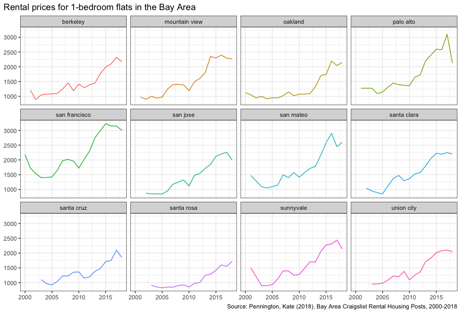

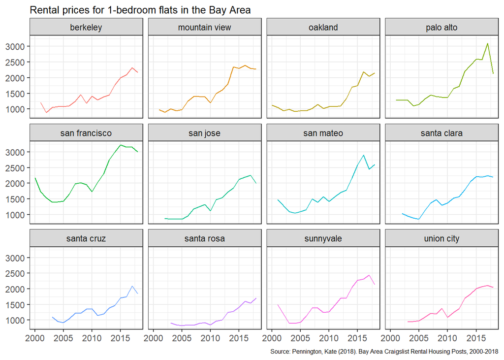

```r
# YOUR CODE GOES HERE
bay_area = c('berkeley', 'mountain view', 'oakland', 'palo alto', 'san francisco', 'san jose', 'san mateo', 'santa clara', 'santa cruz', 'santa rosa', 'sunnyvale', 'union city')

rent %>%
  filter(city %in% bay_area, beds == 1) %>%
  group_by(city, year) %>%
  summarise(median_price = median(price)) %>%
  ggplot() +
  aes(x = year, y = median_price, color = city) +
  geom_line() +
  facet_wrap(~city, ncol = 4) +
  theme_bw() +
  labs(
    title = 'Rental prices for 1-bedroom flats in the Bay Area',
    caption = 'Source: Pennington, Kate (2018). Bay Area Craigslist Rental Housing Posts, 2000-2018',
    x = NULL,
    y = NULL
  ) +
  theme(
    legend.position = "none",
    plot.title = element_text(size = 10, hjust = 0, margin = margin(t = 0, b = 3, l = 0)),
    plot.subtitle = element_text(size = 8, hjust = 0, margin = margin(t = 0, b = 3, l = 0)),
    plot.caption = element_text(size = 6)
  )
```

## 2.1 Challenge

How would you go about creating this?

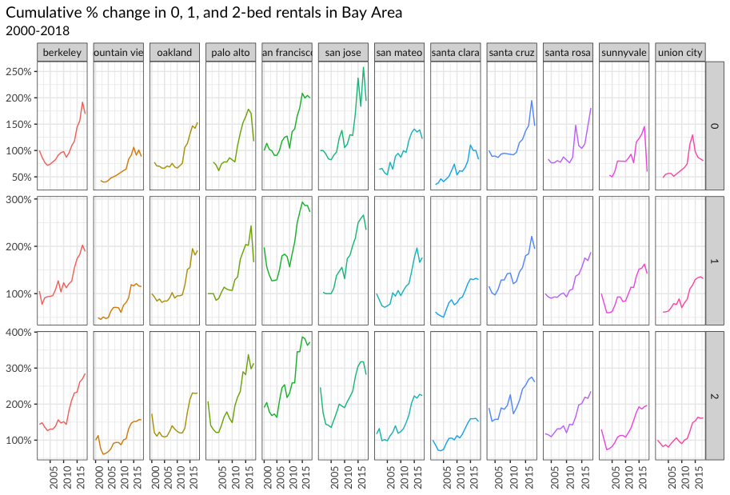

```r
median_rent <- rent %>%
  filter(city %in% bay_area, beds %in% c(0,1,2)) %>%
  group_by(city, beds, year) %>%
  summarise(median_price = median(price, na.rm = TRUE)) %>%
  mutate(
    pct_change = (median_price / first(median_price))
  )
```

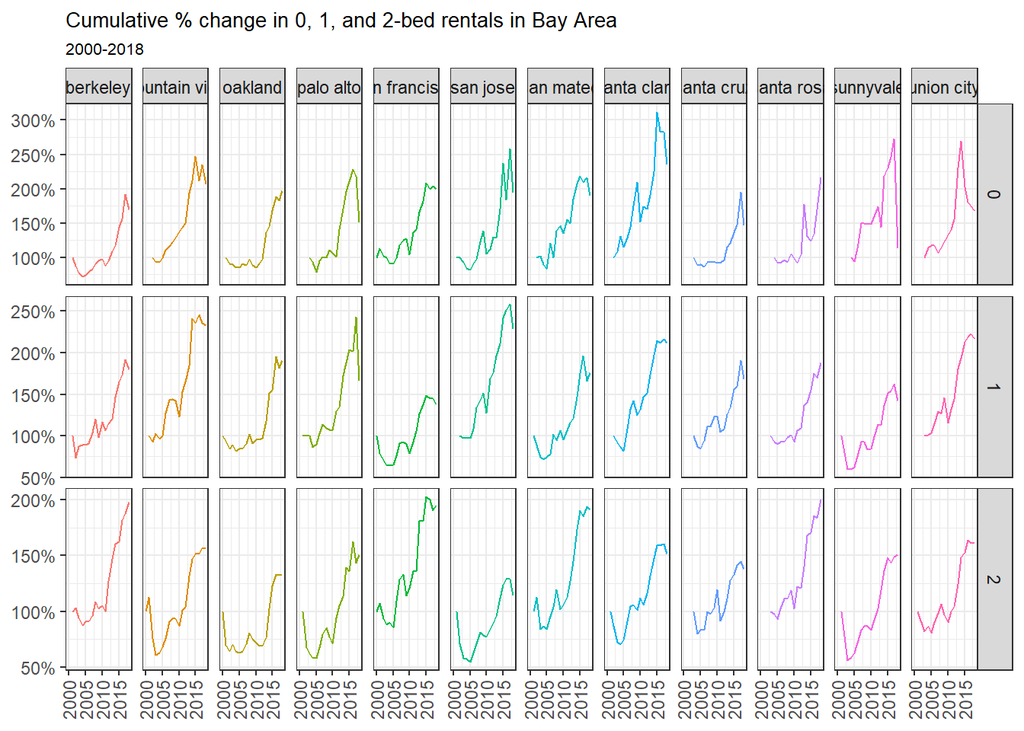

```r
ggplot(median_rent, aes(x = year, y = pct_change, color = city)) +
  geom_line() +  # Draw lines
  facet_grid(beds ~ city, scales = "free_y") +  # Facet by city and beds, free y-axis scaling
  scale_y_continuous(labels = scales::percent_format()) +
  labs(
    title = "Cumulative % change in 0, 1, and 2-bed rentals in Bay Area",
    subtitle = "2000-2018",
    x = NULL,
    y = NULL
  ) +
  theme_bw() +  # Use a minimal theme
  theme(
    plot.title = element_text(hjust = 0, size = 10),
    plot.subtitle = element_text(hjust = 0, size = 8),
    axis.text.x = element_text(angle = 90, vjust = 0.5, hjust = 1),
    legend.position = "none"  # Hide legend
  )
```

# 3 On your own – Hollywood Age Gap

The website https://hollywoodagegap.com is a record of *THE AGE DIFFERENCE IN YEARS BETWEEN MOVIE LOVE INTERESTS*. This is an informational site showing the age gap between movie love interests and the data follows certain rules:

- The two (or more) actors play actual love interests (not just friends, coworkers, or some other non-romantic type of relationship)
- The youngest of the two actors is at least 17 years old
- No animated characters

The age gaps dataset includes “gender” columns, which always contain the values “man” or “woman”. These values appear to indicate how the characters in each film identify and some of these values do not match how the actor identifies. We apologize if any characters are misgendered in the data!

The following is a data dictionary of the variables used

| variable | class | description |
| --- | --- | --- |
| movie_name | character | Name of the film |
| release_year | integer | Release year |
| director | character | Director of the film |
| age_difference | integer | Age difference between the characters in whole years |
| couple_number | integer | An identifier for the couple in case multiple couples are listed for this film |
| actor_1_name | character | The name of the older actor in this couple |
| actor_2_name | character | The name of the younger actor in this couple |
| character_1_gender | character | The gender of the older character, as identified by the person who submitted the data for this couple |
| character_2_gender | character | The gender of the younger character, as identified by the person who submitted the data for this couple |
| actor_1_birthdate | date | The birthdate of the older member of the couple |
| actor_2_birthdate | date | The birthdate of the younger member of the couple |
| actor_1_age | integer | The age of the older actor when the film was released |
| actor_2_age | integer | The age of the younger actor when the film was released |

```r
age_gaps <- readr::read_csv('https://raw.githubusercontent.com/rfordatascience/tidytuesday/master/data/2023/2023-02-14/age_gaps.csv')
```

How would you explore this data set? Here are some ideas of tables/ graphs to help you with your analysis

- How is `age_difference` distributed? What’s the ‘typical’ `age_difference` in movies?

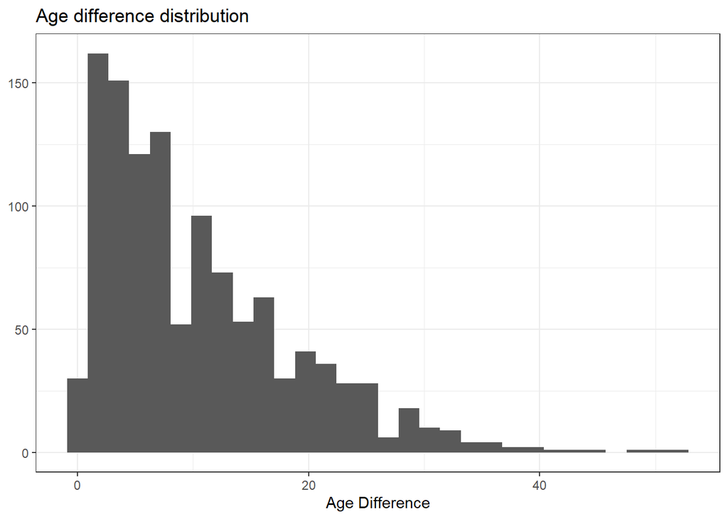

```r
age_gaps %>%
  ggplot() +
  aes(x = age_difference) +
  geom_histogram() +
  theme_bw() +
  labs(
    x = 'Age Difference',
    y = NULL,
    title = 'Age difference distribution'
  )
```

- The `half plus seven\` rule. Large age disparities in relationships carry certain stigmas. One popular rule of thumb is the [half-your-age-plus-seven](https://en.wikipedia.org/wiki/Age_disparity_in_sexual_relationships#The_.22half-your-age-plus-seven.22_rule) rule. This rule states you should never date anyone under half your age plus seven, establishing a minimum boundary on whom one can date. In order for a dating relationship to be acceptable under this rule, your partner’s age must be:

$$\frac{\text{Your age}}{2} + 7 <
\text{Partner Age} < (\text{Your age} - 7) * 2$$
How frequently does this rule apply in this dataset?

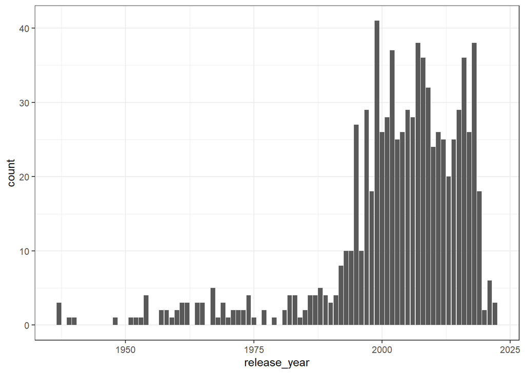

```r
age_diff_followed <- age_gaps %>%
  mutate(
    min_acceptable_age = actor_1_age / 2 + 7,
    max_acceptable_age = (actor_1_age - 7) * 2,
    follows_rule = actor_2_age >= min_acceptable_age & actor_2_age <= max_acceptable_age
  )
age_diff_followed %>%
  filter(follows_rule == TRUE) %>%
  group_by(release_year) %>%
  ggplot() +
  aes(x = release_year) +
  geom_bar() +
  theme_bw()
```

```r
# Summarize the results
summary <- age_diff_followed %>%
  summarise(
    total_couples = n(),
    couples_following_rule = sum(follows_rule),
    proportion_following_rule = mean(follows_rule)
  )

print(summary)
```

```
## # A tibble: 1 × 3
##   total_couples couples_following_rule proportion_following_rule
##           <int>                  <int>                     <dbl>
## 1          1155                    829                     0.718
```

- Which movie has the greatest number of love interests?

```r
movie_couples <- age_gaps %>%
  group_by(movie_name) %>%
  summarise(love_interests = n())

# Find the movie with the greatest number of love interests
movie_with_most_love_interests <- movie_couples %>%
  arrange(desc(love_interests)) %>%
  slice(1)

# Print the result
print(movie_with_most_love_interests)
```

```
## # A tibble: 1 × 2
##   movie_name    love_interests
##   <chr>                  <int>
## 1 Love Actually              7
```

- Which actors/ actresses have the greatest number of love interests in this dataset?

```r
# Combine actor_1 and actor_2 into a unified format for counting love interests
love_interests <- age_gaps %>%
  select(actor_1_name, actor_2_name, movie_name, couple_number) %>%
  gather(key = "actor_role", value = "actor_name", actor_1_name, actor_2_name) %>%
  distinct(actor_name, movie_name, couple_number)

# Group by actor_name and count the number of unique love interests
actor_love_interests <- love_interests %>%
  group_by(actor_name) %>%
  summarise(love_interests = n()) %>%
  arrange(desc(love_interests))

# Find the actors with the greatest number of love interests
actors_with_most_love_interests <- actor_love_interests %>%
  filter(love_interests == max(love_interests))

# Print the result
print(actors_with_most_love_interests)
```

```
## # A tibble: 1 × 2
##   actor_name   love_interests
##   <chr>                 <int>
## 1 Keanu Reeves             27
```

- Is the mean/median age difference staying constant over the years (1935 - 2022)?

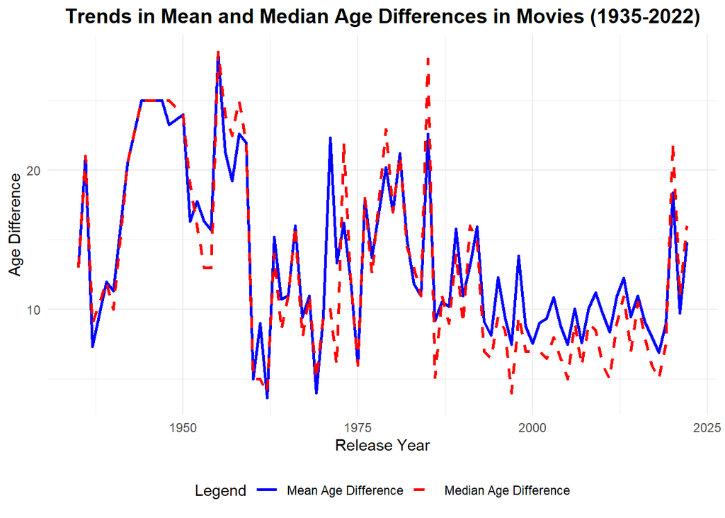

```r
# Filter the data for the years 1935 to 2022
age_gaps_filtered <- age_gaps %>%
  filter(release_year >= 1935 & release_year <= 2022)

# Calculate mean and median age differences for each year
age_difference_trends <- age_gaps_filtered %>%
  group_by(release_year) %>%
  summarise(
    mean_age_difference = mean(age_difference, na.rm = TRUE),
    median_age_difference = median(age_difference, na.rm = TRUE)
  )

# Plot the results
ggplot(age_difference_trends, aes(x = release_year)) +
  geom_line(aes(y = mean_age_difference, color = "Mean Age Difference"), linewidth = 1) +
  geom_line(aes(y = median_age_difference, color = "Median Age Difference"), linewidth = 1, linetype = "dashed") +
  labs(
    title = "Trends in Mean and Median Age Differences in Movies (1935-2022)",
    x = "Release Year",
    y = "Age Difference",
    color = "Legend"
  ) +
  theme_minimal() +
  scale_color_manual(values = c("Mean Age Difference" = "blue", "Median Age Difference" = "red")) +
  theme(
    plot.title = element_text(hjust = 0.5, size = 14, face = "bold"),
    legend.position = "bottom"
  )
```

- How frequently does Hollywood depict same-gender love interests?

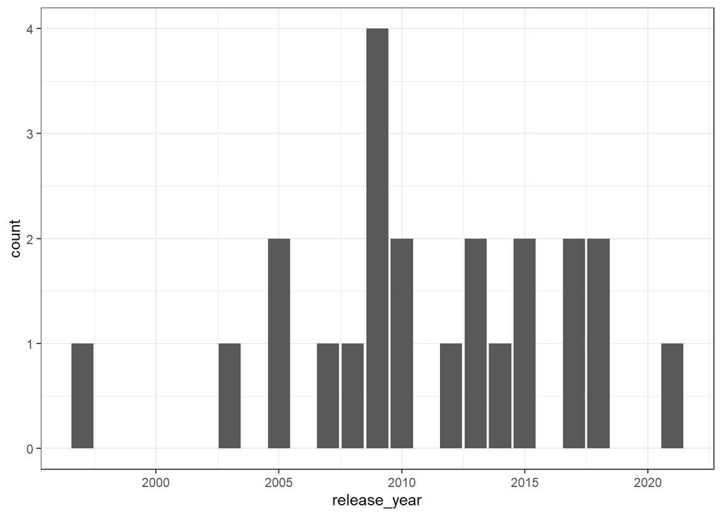

```r
age_gaps_same_gender <- age_gaps %>%
  mutate(
    same_gender = character_1_gender == character_2_gender
  )
age_gaps_same_gender %>%
  group_by(release_year) %>%
  filter(same_gender == TRUE) %>%
  ggplot() +
  aes(x = release_year) +
  geom_bar() +
  theme_bw()
```

```r
# Calculate the frequency of same-gender couples
same_gender_summary <- age_gaps_same_gender %>%
  summarise(
    total_couples = n(),
    same_gender_couples = sum(same_gender, na.rm = TRUE),
    proportion_same_gender = mean(same_gender, na.rm = TRUE)
  )

# Print the summary
print(same_gender_summary)
```

```
## # A tibble: 1 × 3
##   total_couples same_gender_couples proportion_same_gender
##           <int>               <int>                  <dbl>
## 1          1155                  23                 0.0199
```

# 4 Deliverables

There is a lot of explanatory text, comments, etc. You do not need these, so delete them and produce a stand-alone document that you could share with someone. Render the edited and completed Quarto Markdown (qmd) file as a Word document (use the “Render” button at the top of the script editor window) and upload it to Canvas. You must be commiting and pushing tour changes to your own Github repo as you go along.

# 5 Details

- Who did you collaborate with: N/A
- Approximately how much time did you spend on this problem set: ~5 hours
- What, if anything, gave you the most trouble: Recreating the graphs, mainly formatting the graphs as per the image. I could not get the title and subtitle to align correctly.

**Please seek out help when you need it,** and remember the [15-minute rule](https://mam2022.netlify.app/syllabus/#the-15-minute-rule). You know enough R (and have enough examples of code from class and your readings) to be able to do this. If you get stuck, ask for help from others, post a question on Slack– and remember that I am here to help too!

> As a true test to yourself, do you understand the code you submitted and are you able to explain it to someone else?

> Yes

# 6 Rubric

13/13: Problem set is 100% completed. Every question was attempted and answered, and most answers are correct. Code is well-documented (both self-documented and with additional comments as necessary). Used tidyverse, instead of base R. Graphs and tables are properly labelled. Analysis is clear and easy to follow, either because graphs are labeled clearly or you’ve written additional text to describe how you interpret the output. Multiple Github commits. Work is exceptional. I will not assign these often.

8/13: Problem set is 60–80% complete and most answers are correct. This is the expected level of performance. Solid effort. Hits all the elements. No clear mistakes. Easy to follow (both the code and the output). A few Github commits.

5/13: Problem set is less than 60% complete and/or most answers are incorrect. This indicates that you need to improve next time. I will hopefully not assign these often. Displays minimal effort. Doesn’t complete all components. Code is poorly written and not documented. Uses the same type of plot for each graph, or doesn’t use plots appropriate for the variables being analyzed. No Github commits.